# Dan & Justin’s data analysis

JF GOUT

3/9/2021

## Introduction

This RNAseq dataset is looking at gene expression in Mice infected with *Streptococcus pneumoniae* for two different genotypes: WT and PUMA knock-out. 5 mice from each genotype were mock infected (PBS) or infected (Spn) –> 20 mice total.  
RNAseq reads were trimmed for quality and TPM values were computed using Kallisto. Differential gene expression is performed using DEseq2.

The following table summarizes the data used as input for the DEseq2 analysis:

|  | mouse_id | genotype | sex | stimulus | i7_primer | i7_index | i5_primer | i5_index | file |
| --- | --- | --- | --- | --- | --- | --- | --- | --- | --- |
| 854_WT_M_Spn | 854 | WT | M | Spn | i701 | ATTACTCG | i501 | TATAGCCT | Kallisto-103-trimmed/854WT.h5 |
| 859_WT_F_Spn | 859 | WT | F | Spn | i703 | CGCTCATT | i501 | TATAGCCT | Kallisto-103-trimmed/859WT.h5 |
| 860_WT_M_Spn | 860 | WT | M | Spn | i702 | TCCGGAGA | i501 | TATAGCCT | Kallisto-103-trimmed/860WT.h5 |
| 864_WT_F_Spn | 864 | WT | F | Spn | i704 | GAGATTCC | i501 | TATAGCCT | Kallisto-103-trimmed/864WT.h5 |
| 868_WT_F_Spn | 868 | WT | F | Spn | i705 | ATTCAGAA | i501 | TATAGCCT | Kallisto-103-trimmed/868WT.h5 |
| 406_KO_M_Spn | 406 | KO | M | Spn | i703 | CGCTCATT | i501 | TATAGCCT | Kallisto-103-trimmed/406KO.h5 |
| 413_KO_F_Spn | 413 | KO | F | Spn | i704 | GAGATTCC | i501 | TATAGCCT | Kallisto-103-trimmed/413KO.h5 |
| 867_KO_F_Spn | 867 | KO | F | Spn | i701 | ATTACTCG | i503 | CCTATCCT | Kallisto-103-trimmed/867KO.h5 |
| 870_KO_F_Spn | 870 | KO | F | Spn | i705 | ATTCAGAA | i501 | TATAGCCT | Kallisto-103-trimmed/870KO.h5 |
| 872_KO_M_Spn | 872 | KO | M | Spn | i702 | TCCGGAGA | i501 | TATAGCCT | Kallisto-103-trimmed/872KO.h5 |
| 408_WT_M_PBS | 408 | WT | M | PBS | i703 | CGCTCATT | i505 | AGGCGAAG | Kallisto-103-trimmed/408WT.h5 |
| 415_WT_F_PBS | 415 | WT | F | PBS | i709 | CGGCTATG | i502 | ATAGAGGC | Kallisto-103-trimmed/415WT.h5 |
| 889_WT_F_PBS | 889 | WT | F | PBS | i708 | TAATGCGC | i502 | ATAGAGGC | Kallisto-103-trimmed/889WT.h5 |
| 890_WT_M_PBS | 890 | WT | M | PBS | i702 | TCCGGAGA | i504 | GGCTCTGA | Kallisto-103-trimmed/890WT.h5 |
| 894_WT_M_PBS | 894 | WT | M | PBS | i707 | CTGAAGCT | i502 | ATAGAGGC | Kallisto-103-trimmed/894WT.h5 |
| 402_KO_F_PBS | 402 | KO | F | PBS | i706 | GAATTCGT | i502 | ATAGAGGC | Kallisto-103-trimmed/402KO.h5 |
| 409_KO_F_PBS | 409 | KO | F | PBS | i709 | CGGCTATG | i502 | ATAGAGGC | Kallisto-103-trimmed/409KO.h5 |
| 411_KO_M_PBS | 411 | KO | M | PBS | i710 | TCCGCGAA | i502 | ATAGAGGC | Kallisto-103-trimmed/411KO.h5 |
| 893_KO_M_PBS | 893 | KO | M | PBS | i708 | TAATGCGC | i502 | ATAGAGGC | Kallisto-103-trimmed/893KO.h5 |
| 900_KO_F_PBS | 900 | KO | F | PBS | i707 | CTGAAGCT | i502 | ATAGAGGC | Kallisto-103-trimmed/900KO.h5 |

## Results.

### Genes differentially expressed:

First, I searched for genes with a different reaction to infection between the two genotypes. This is done in DEseq2 with the following formula:

```r
design = ~ genotype + stimulus + genotype:stimulus
```

I restricted the input to genes with sum of counts > 100 (resulting in keeping 36119 genes out of 140725 total genes in the genome). This steps removes genes with very few reads across all samples (= genes that are never expressed during the experiment). The main reason to do so is to reduce the size of the input to speed up calculation and mostly to increase statistical power (fewer genes as input -> more power during correction for multiple testing).

With these parameters, DEseq2 finds 8 deferentially expressed genes (with adjusted p-value < 0.05).

List of significant genes:

|  | baseMean | log2FoldChange | lfcSE | stat | pvalue | padj |
| --- | --- | --- | --- | --- | --- | --- |
| ENSMUSG00000011256 | 1374.1214 | -0.6145045 | 0.1049396 | -5.855791 | 0.0e+00 | 0.0000277 |
| ENSMUSG00000019767 | 230.0602 | 0.8356219 | 0.1759893 | 4.748139 | 2.1e-06 | 0.0071800 |
| ENSMUSG00000033768 | 290.0493 | -1.5598835 | 0.3358000 | -4.645276 | 3.4e-06 | 0.0098983 |
| ENSMUSG00000052783 | 139.9648 | -1.4020010 | 0.3097542 | -4.526172 | 6.0e-06 | 0.0150043 |
| ENSMUSG00000061665 | 1940.4045 | 0.6727691 | 0.1496292 | 4.496241 | 6.9e-06 | 0.0151186 |
| ENSMUSG00000100862 | 1443.5300 | 27.6178594 | 4.5341299 | 6.091105 | 0.0e+00 | 0.0000098 |
| ENSMUSG00000101111 | 585.6601 | 22.5466239 | 4.4089933 | 5.113780 | 3.0e-07 | 0.0013805 |
| ENSMUSG00000102070 | 12271.1650 | 29.6730699 | 4.8484792 | 6.120078 | 0.0e+00 | 0.0000098 |

## Data quality checks.

The goal of this section is to perform a basic quality check on the data. One way to perform this check is to make sure that samples of the same genotype+stimulus combination cluster together.

### Heatmap

I performed a simple heatmap clustering analysis, using the top 100 most highly expressed genes (note: the clustering does not change when using more genes):

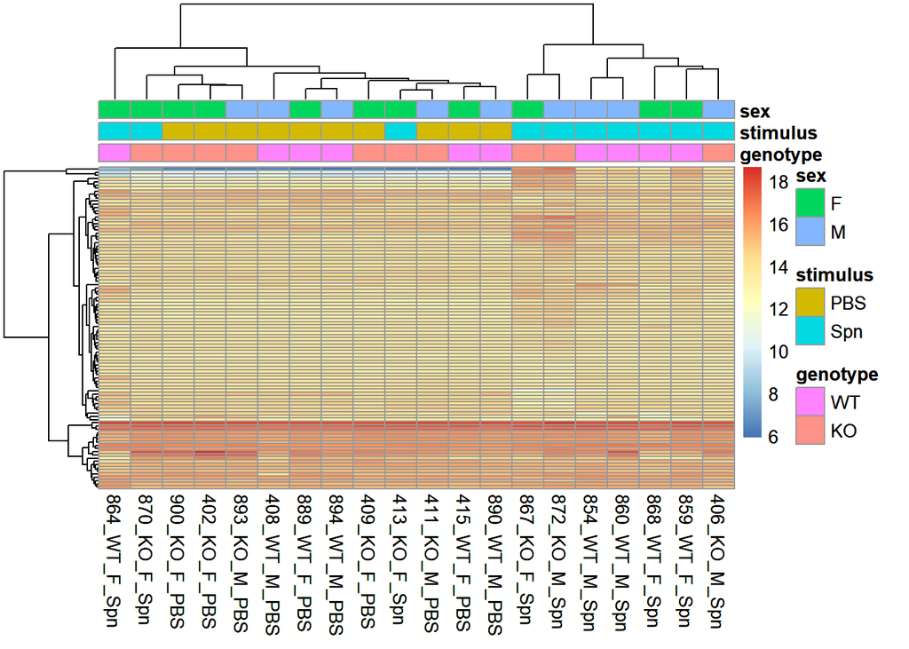

The 3 genes at the top of the heatmap seem to be driving a lot of the clustering (genes with low expression level in the “left” cluster (with mostly PBS) and higher expression level in the “right” cluster which contains only Spn samples) are:

```
## [1] "ENSMUSG00000034855" "ENSMUSG00000028270" "ENSMUSG00000054072"
```

### Sample to sample distance:

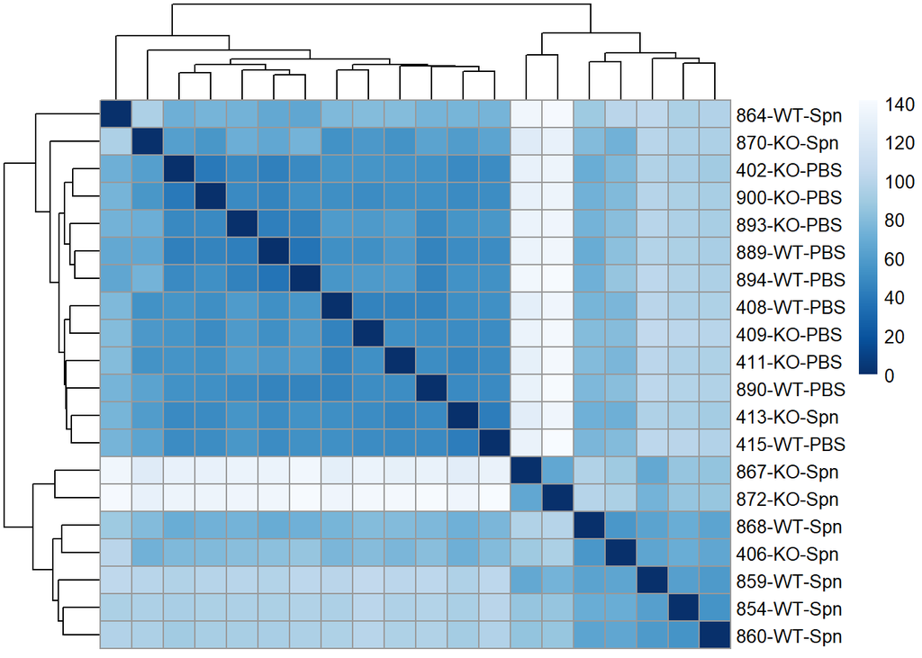

Both analyzes point at 3 Spn samples (Mice 870, 413, 864) clustering with the PBS samples, which makes me suspect that these 3 samples should be removed from the analysis. So, I repeated the analysis after removing them.

## Analysis with outliers removed

After removing these 3 outliers, DEseq2 finds 26 deferentially expressed genes (with adjusted p-value < 0.05).

|  | baseMean | log2FoldChange | lfcSE | stat | pvalue | padj |
| --- | --- | --- | --- | --- | --- | --- |
| ENSMUSG00000004455 | 2711.33411 | 0.4152698 | 0.1044963 | 3.974016 | 7.07e-05 | 0.0488716 |
| ENSMUSG00000010047 | 961.76622 | -1.4158723 | 0.3509715 | -4.034153 | 5.48e-05 | 0.0471771 |
| ENSMUSG00000011256 | 1360.22333 | -0.5996373 | 0.1168308 | -5.132529 | 3.00e-07 | 0.0012305 |
| ENSMUSG00000019866 | 812.41746 | 1.0940206 | 0.2694368 | 4.060398 | 4.90e-05 | 0.0443944 |
| ENSMUSG00000019987 | 73.43338 | 1.9458461 | 0.4909172 | 3.963695 | 7.38e-05 | 0.0488716 |
| ENSMUSG00000020747 | 1136.45415 | -0.7164022 | 0.1794420 | -3.992389 | 6.54e-05 | 0.0488716 |
| ENSMUSG00000021322 | 155.45765 | 1.7592744 | 0.4241266 | 4.147994 | 3.35e-05 | 0.0360934 |
| ENSMUSG00000024168 | 2267.82514 | -1.1603298 | 0.2751220 | -4.217511 | 2.47e-05 | 0.0327161 |
| ENSMUSG00000029174 | 878.06863 | 0.9109598 | 0.2224740 | 4.094681 | 4.23e-05 | 0.0404385 |
| ENSMUSG00000029675 | 3111.23756 | -1.5899382 | 0.3053417 | -5.207078 | 2.00e-07 | 0.0011010 |
| ENSMUSG00000033088 | 852.86810 | 0.9027442 | 0.2245027 | 4.021084 | 5.79e-05 | 0.0474979 |
| ENSMUSG00000033768 | 271.15091 | -1.6190659 | 0.2589199 | -6.253153 | 0.00e+00 | 0.0000069 |
| ENSMUSG00000036943 | 1745.18539 | 0.8981500 | 0.2147296 | 4.182702 | 2.88e-05 | 0.0335880 |
| ENSMUSG00000038065 | 963.44324 | -0.8339767 | 0.1899090 | -4.391453 | 1.13e-05 | 0.0176243 |
| ENSMUSG00000045114 | 56.82401 | -2.0639354 | 0.4221004 | -4.889679 | 1.00e-06 | 0.0033118 |
| ENSMUSG00000048200 | 1186.40948 | -0.9426568 | 0.2177236 | -4.329603 | 1.49e-05 | 0.0214333 |
| ENSMUSG00000052105 | 1507.14059 | -0.6787543 | 0.1706338 | -3.977843 | 6.95e-05 | 0.0488716 |
| ENSMUSG00000052783 | 140.01323 | -1.6006875 | 0.3390607 | -4.720947 | 2.30e-06 | 0.0046521 |
| ENSMUSG00000070417 | 22.99221 | 2.3754333 | 0.5253767 | 4.521390 | 6.10e-06 | 0.0105778 |
| ENSMUSG00000070576 | 194.86223 | -1.7174026 | 0.4331092 | -3.965288 | 7.33e-05 | 0.0488716 |
| ENSMUSG00000074647 | 22.05232 | 2.3898199 | 0.5718448 | 4.179141 | 2.93e-05 | 0.0335880 |
| ENSMUSG00000078087 | 119.68441 | -30.0000000 | 6.1685714 | -4.863363 | 1.20e-06 | 0.0033118 |
| ENSMUSG00000093979 | 25.06645 | 2.0496212 | 0.4958552 | 4.133507 | 3.57e-05 | 0.0361850 |
| ENSMUSG00000095597 | 233.84010 | 25.1921349 | 4.4974209 | 5.601463 | 0.00e+00 | 0.0001830 |
| ENSMUSG00000100862 | 1621.89809 | 27.6385070 | 5.8633472 | 4.713776 | 2.40e-06 | 0.0046521 |
| ENSMUSG00000102070 | 11894.22750 | 28.6122961 | 5.9858800 | 4.779965 | 1.80e-06 | 0.0043125 |

Genes ‘added’ to the list of significant genes: ENSMUSG00000004455, ENSMUSG00000010047, ENSMUSG00000019866, ENSMUSG00000019987, ENSMUSG00000020747, ENSMUSG00000021322, ENSMUSG00000024168, ENSMUSG00000029174, ENSMUSG00000029675, ENSMUSG00000033088, ENSMUSG00000036943, ENSMUSG00000038065, ENSMUSG00000045114, ENSMUSG00000048200, ENSMUSG00000052105, ENSMUSG00000070417, ENSMUSG00000070576, ENSMUSG00000074647, ENSMUSG00000078087, ENSMUSG00000093979, ENSMUSG00000095597

Genes ‘removed’ from the list of significant genes: ENSMUSG00000019767, ENSMUSG00000061665, ENSMUSG00000101111

## Gene ontology analysis.

I used the package topGO to search for GO categories over-represented within deferentially expressed genes.

## Biological processes:

I found 28 functional categories with adjusted p-value < 0.05 (using the fdr method to adjust p-values for multiple testing):

|  | GO.ID | Term | Annotated | Significant | Expected | pval | padj | FE |
| --- | --- | --- | --- | --- | --- | --- | --- | --- |
| 1 | GO:0035458 | cellular response to interferon-beta | 47 | 29 | 5.48 | 0.0e+00 | 0.0000000 | 5.291971 |
| 8 | GO:0042832 | defense response to protozoan | 36 | 17 | 4.19 | 3.0e-07 | 0.0002605 | 4.057279 |
| 25 | GO:0032494 | response to peptidoglycan | 13 | 6 | 1.51 | 7.3e-05 | 0.0190180 | 3.973510 |
| 26 | GO:0031663 | lipopolysaccharide-mediated signaling pathway | 50 | 22 | 5.83 | 9.4e-05 | 0.0235470 | 3.773585 |
| 7 | GO:0071346 | cellular response to interferon-gamma | 109 | 44 | 12.70 | 3.0e-07 | 0.0002605 | 3.464567 |
| 21 | GO:0032735 | positive regulation of interleukin-12 production | 38 | 15 | 4.43 | 3.0e-05 | 0.0093043 | 3.386004 |
| 5 | GO:0071222 | cellular response to lipopolysaccharide | 166 | 62 | 19.34 | 0.0e+00 | 0.0000018 | 3.205791 |
| 18 | GO:0032731 | positive regulation of interleukin-1 beta production | 51 | 19 | 5.94 | 1.4e-05 | 0.0050657 | 3.198653 |
| 28 | GO:0070498 | interleukin-1-mediated signaling pathway | 22 | 8 | 2.56 | 1.4e-04 | 0.0325650 | 3.125000 |
| 9 | GO:0050830 | defense response to Gram-positive bacterium | 83 | 29 | 9.67 | 4.0e-07 | 0.0003039 | 2.998966 |
| 15 | GO:0002720 | positive regulation of cytokine production involved in immune response | 52 | 18 | 6.06 | 8.6e-06 | 0.0037341 | 2.970297 |
| 2 | GO:0051607 | defense response to virus | 218 | 74 | 25.40 | 0.0e+00 | 0.0000001 | 2.913386 |
| 22 | GO:0045824 | negative regulation of innate immune response | 59 | 20 | 6.87 | 3.6e-05 | 0.0106576 | 2.911208 |
| 12 | GO:0045071 | negative regulation of viral genome replication | 54 | 18 | 6.29 | 7.2e-06 | 0.0037341 | 2.861685 |
| 4 | GO:0043123 | positive regulation of I-kappaB kinase/NF-kappaB signaling | 123 | 41 | 14.33 | 0.0e+00 | 0.0000002 | 2.861130 |
| 16 | GO:0009620 | response to fungus | 41 | 12 | 4.78 | 1.2e-05 | 0.0048848 | 2.510460 |
| 3 | GO:0045087 | innate immune response | 644 | 187 | 75.04 | 0.0e+00 | 0.0000001 | 2.492004 |
| 17 | GO:0061844 | antimicrobial humoral immune response mediated by antimicrobial peptide | 64 | 18 | 7.46 | 1.3e-05 | 0.0049805 | 2.412869 |
| 14 | GO:0009617 | response to bacterium | 580 | 158 | 67.58 | 8.4e-06 | 0.0037341 | 2.337970 |
| 27 | GO:0071356 | cellular response to tumor necrosis factor | 142 | 38 | 16.55 | 1.0e-04 | 0.0241222 | 2.296073 |
| 23 | GO:0032757 | positive regulation of interleukin-8 production | 49 | 13 | 5.71 | 3.8e-05 | 0.0107606 | 2.276708 |
| 20 | GO:0050729 | positive regulation of inflammatory response | 136 | 36 | 15.85 | 2.7e-05 | 0.0087926 | 2.271293 |
| 19 | GO:0050727 | regulation of inflammatory response | 341 | 87 | 39.73 | 2.4e-05 | 0.0082269 | 2.189781 |
| 11 | GO:0033209 | tumor necrosis factor-mediated signaling pathway | 63 | 16 | 7.34 | 3.7e-06 | 0.0021907 | 2.179836 |
| 13 | GO:0006954 | inflammatory response | 655 | 153 | 76.32 | 8.4e-06 | 0.0037341 | 2.004717 |
| 10 | GO:0006955 | immune response | 1320 | 300 | 153.80 | 1.1e-06 | 0.0007164 | 1.950585 |
| 6 | GO:0051092 | positive regulation of NF-kappaB transcription factor activity | 141 | 29 | 16.43 | 2.0e-07 | 0.0002605 | 1.765064 |
| 24 | GO:0045944 | positive regulation of transcription by RNA polymerase II | 1092 | 155 | 127.23 | 6.1e-05 | 0.0165539 | 1.218266 |

Looking at the difference in log fold change for WT vs PUMA KO for GO:0035458:

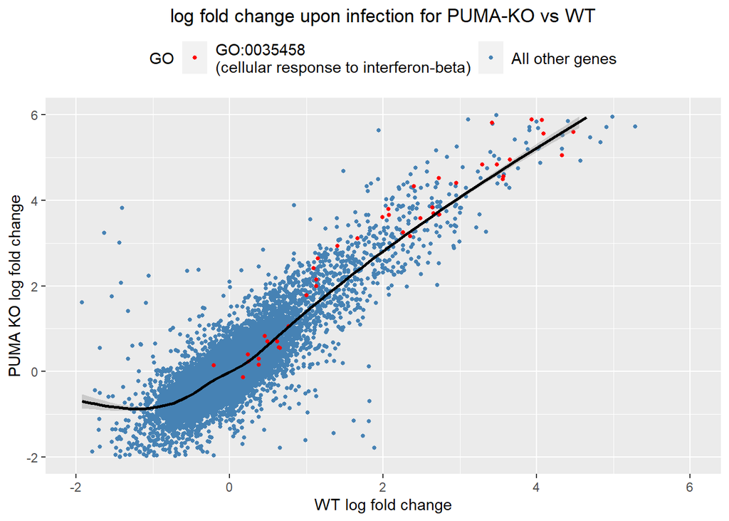

## Molecular functions:

|  | GO.ID | Term | Annotated | Significant | Expected | pval | padj | FE |
| --- | --- | --- | --- | --- | --- | --- | --- | --- |
| 1 | GO:0050700 | CARD domain binding | 12 | 7 | 1.40 | 5.7e-06 | 0.0047920 | 5.000000 |
| 4 | GO:0046977 | TAP binding | 12 | 6 | 1.40 | 3.3e-05 | 0.0098835 | 4.285714 |
| 2 | GO:0008009 | chemokine activity | 40 | 19 | 4.67 | 8.6e-06 | 0.0047920 | 4.068523 |
| 3 | GO:0048020 | CCR chemokine receptor binding | 33 | 15 | 3.85 | 1.2e-05 | 0.0047920 | 3.896104 |

## Cellular components:

|  | GO.ID | Term | Annotated | Significant | Expected | pval | padj | FE |
| --- | --- | --- | --- | --- | --- | --- | --- | --- |
| 6 | GO:0065010 | extracellular membrane-bounded organelle | 11 | 7 | 1.27 | 3.0e-04 | 0.0347143 | 5.511811 |
| 7 | GO:0033646 | host intracellular part | 11 | 7 | 1.27 | 3.0e-04 | 0.0347143 | 5.511811 |
| 3 | GO:0042824 | MHC class I peptide loading complex | 15 | 6 | 1.74 | 1.6e-05 | 0.0038475 | 3.448276 |
| 1 | GO:0005615 | extracellular space | 1224 | 208 | 141.58 | 0.0e+00 | 0.0000000 | 1.469134 |
| 5 | GO:0005829 | cytosol | 3336 | 472 | 385.89 | 2.6e-04 | 0.0347143 | 1.223146 |
| 2 | GO:0005783 | endoplasmic reticulum | 1501 | 207 | 173.63 | 1.3e-05 | 0.0038475 | 1.192190 |
| 4 | GO:0005886 | plasma membrane | 4235 | 536 | 489.88 | 1.9e-05 | 0.0038475 | 1.094145 |